# graphR 1: Introduction

Lise Vaudor

21 mars 2017

# Introduction

**ggplot2** = un package hyper fashion.

ggplot2 est utilisé pour réaliser des graphiques selon une philosophie qui lui est propre (en l’occurrence, inspirée du livre “The **G**rammar of **G**raphics” de Leland Wilkinson, d’où son nom ggplot), et qui le distingue des autres outils de production graphique sous R, notamment les fonctions graphiques “de base” comme “hist”, “boxplot”, etc.

L’idée générale est de **décrire** et donc **produire** un **graphique** comme un **assemblage de couches**

=> production **simple** et **intuitive** de graphiques **beaux** et **riches**

Commençons par charger le package `ggplot2` -après l’avoir, si nécessaire, installé- :

```r
require(ggplot2)
```

# Jeu de données illustratif

Pour vous illustrer les principes et résultats graphiques du package `ggplot2`, je vais utiliser le jeu de données `catdata`, qui comprend les variables:

```r
catdata <- read.csv("../../datasets/catdata.csv", sep=";")
head(catdata)
```

```
##   haircolor hairpattern    sex weight age foodtype
## 1       red       solid female    4.6  12    other
## 2     black       tabby female    5.5   6      dry
## 3     white       tabby female    5.6   8      wet
## 4       red       tabby female    6.1   5      dry
## 5     brown       solid female    5.3   7      dry
## 6     black       tabby   male    6.9   5      wet
```

- **haircolor**: la couleur du poil (catégoriel)
- **hairpattern**: le “pattern” coloré du poil (catégoriel)
- **sex**: le sexe du chat (catégoriel)
- **weight**: son poids (quantitatif)
- **age**: son âge (quantitatif)
- **foodtype**: le type d’alimentation (catégoriel)

# Les bases: jeu de données, aethetics, et geoms

On **crée** un graphique à l’aide de la fonction **ggplot**. On spécifie sur quel **jeu de données** le graphique va être construit, ainsi que les **aesthetics** x et y:

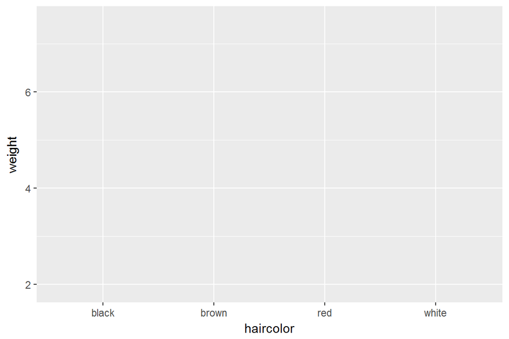

```r
p <- ggplot(catdata,aes(x=haircolor,y=weight))
plot(p)
```

Choisissons par exemple de représenter l’information à l’aide d’un **geom “point”**:

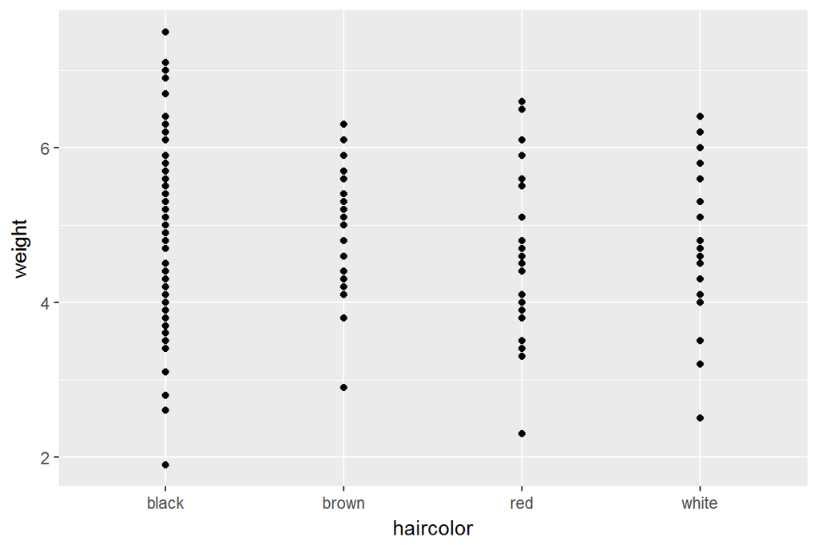

```r
p <- ggplot(catdata,aes(x=haircolor,y=weight)) +
  geom_point()
plot(p)
```

# Modification du type de geom

Si je souhaite réaliser un graphique de type **boxplot** plutôt que point alors il faut que je modifie le **type de geom** que j’utilise :

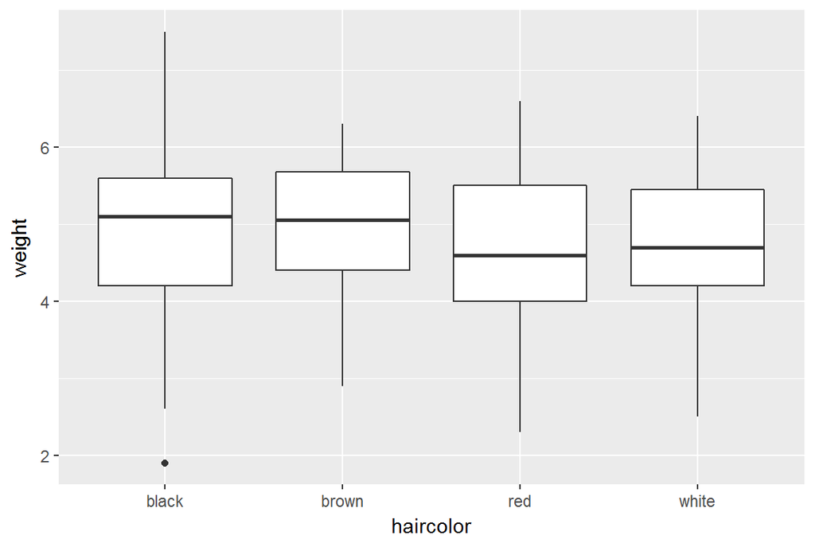

```r
p <- ggplot(catdata,aes(x=haircolor,y=weight)) +
  geom_boxplot()
plot(p)
```

## Remarque

Vous devez choisir un **type de geom compatible avec la nature des informations** (en x et y) que vous voulez représenter!

```r
p <- ggplot(catdata,aes(x=haircolor)) +
  geom_point()
plot(p)
```

```
## Error: geom_point requires the following missing aesthetics: y
```

# Modification du type de geom

## Graphique univarié, x discrète

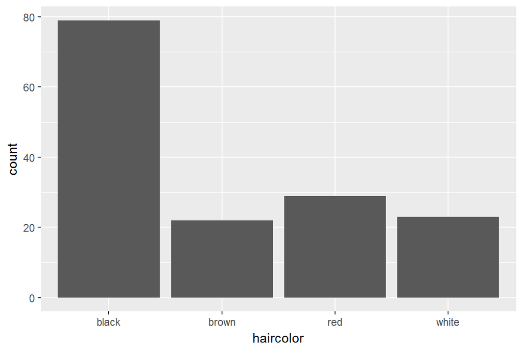

```r
p <- ggplot(catdata,aes(x=haircolor)) +
  geom_bar()
plot(p)
```

## Graphique univarié, x continue

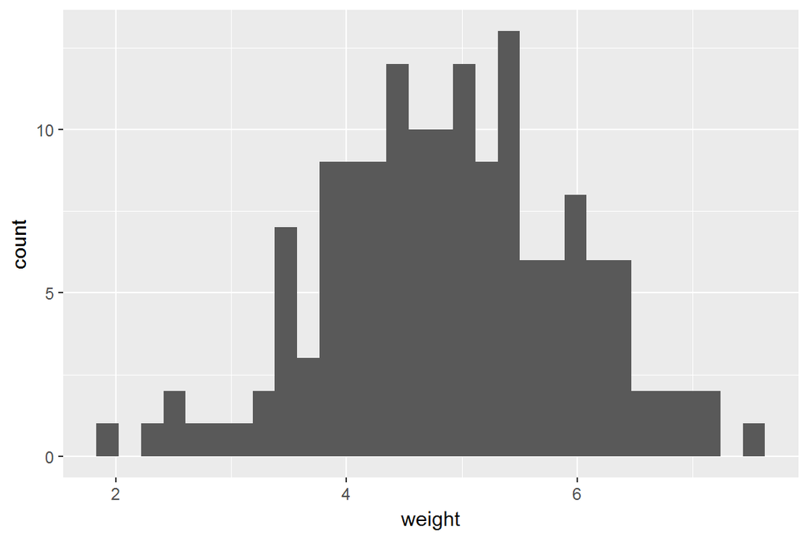

```r
p <- ggplot(catdata,aes(x=weight)) +
  geom_histogram()
plot(p)
```

# Modification du type de geom

## Bivarié, x et y continues

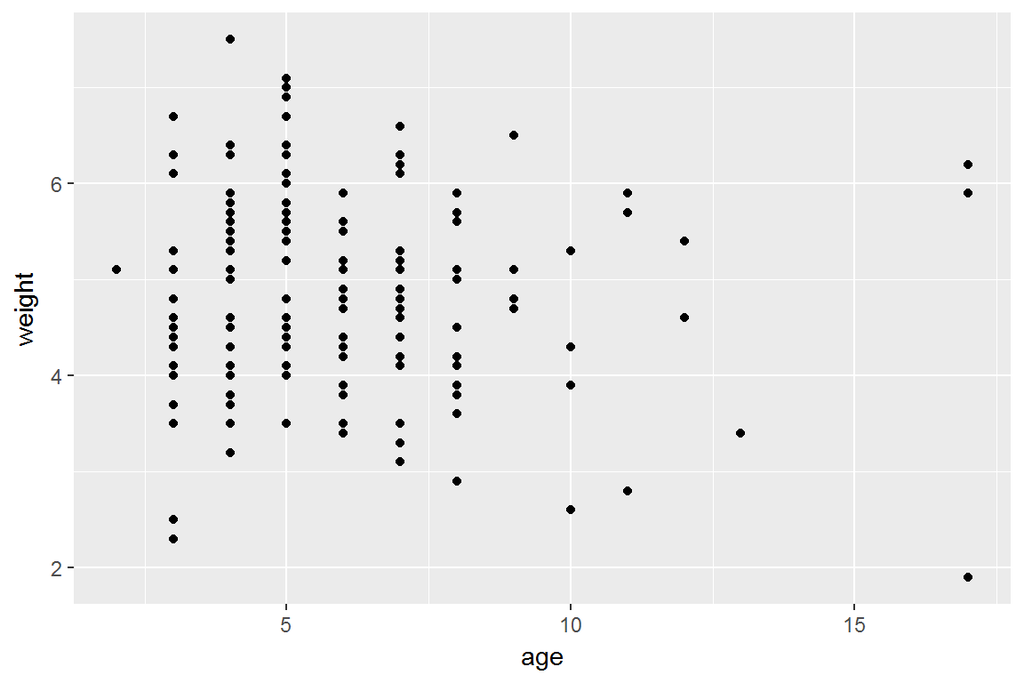

```r
p <- ggplot(catdata,aes(x=age, y=weight)) +
  geom_point()
plot(p)
```

## Bivarié, x et y continues

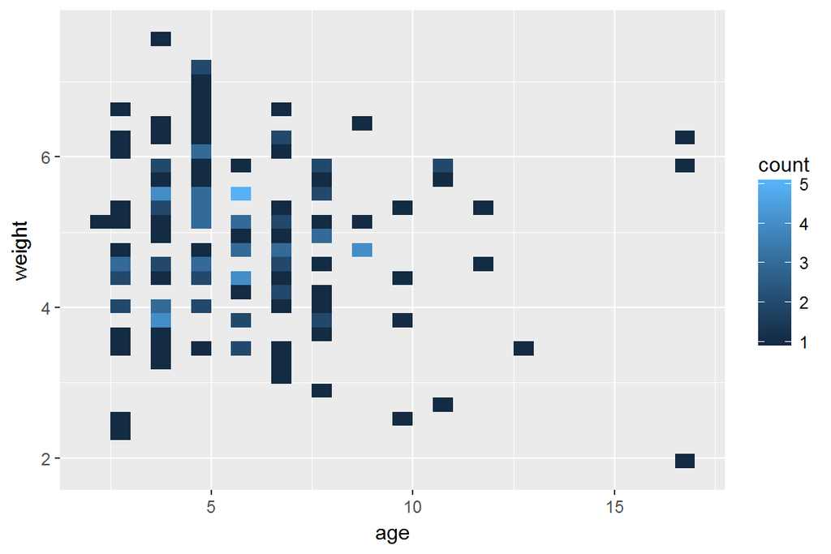

```r
p <- ggplot(catdata,aes(x=age, y=weight)) +
  geom_bin2d()
plot(p)
```

# Modification du type de geom

## Bivarié, x discrète et y continue

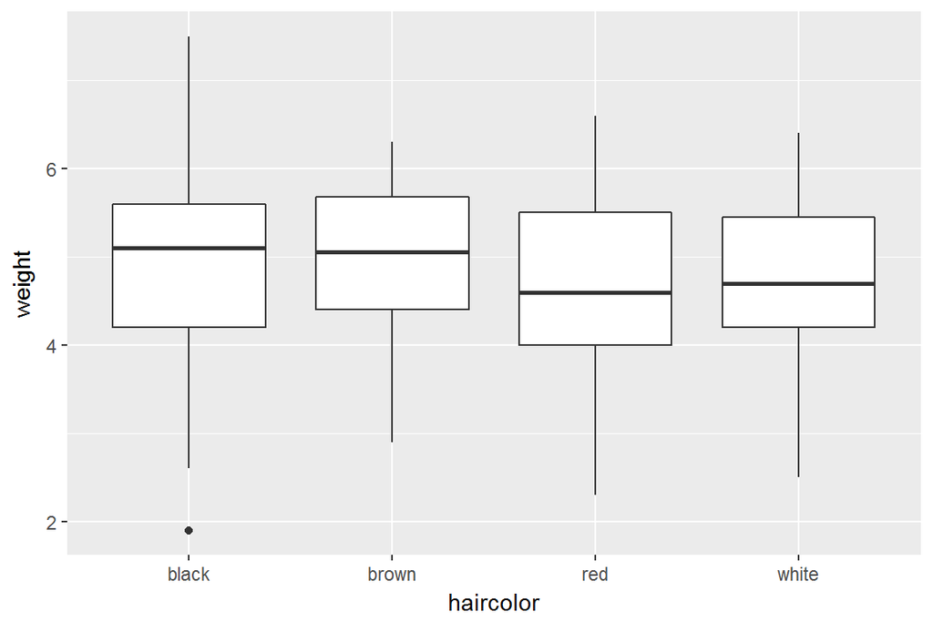

```r
p <- ggplot(catdata,aes(x=haircolor, y=weight)) +
  geom_boxplot()
plot(p)
```

## Bivarié, x discrète et y continue

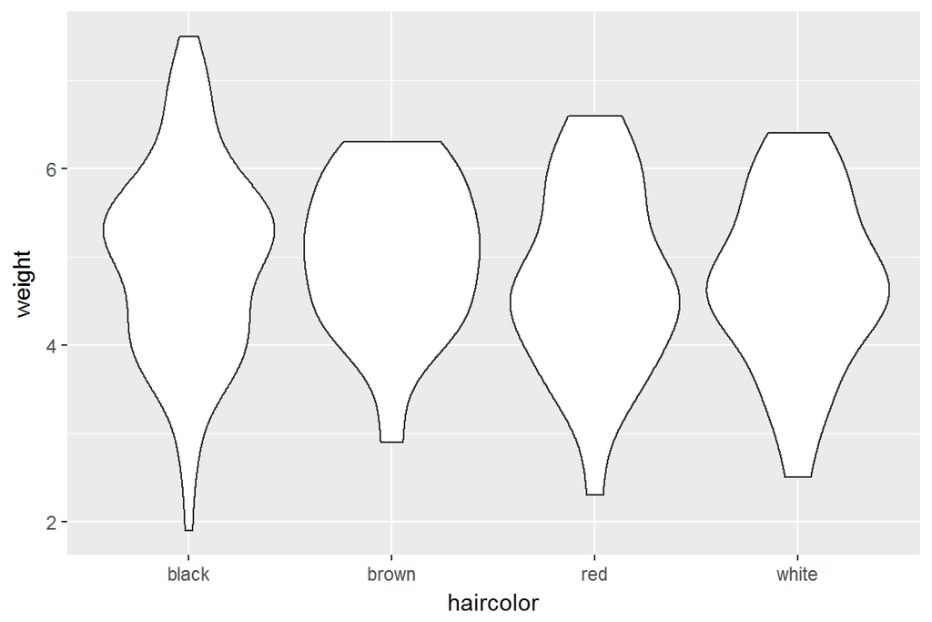

```r
p <- ggplot(catdata,aes(x=haircolor, y=weight)) +
  geom_violin()
plot(p)
```

# Superposition de geoms

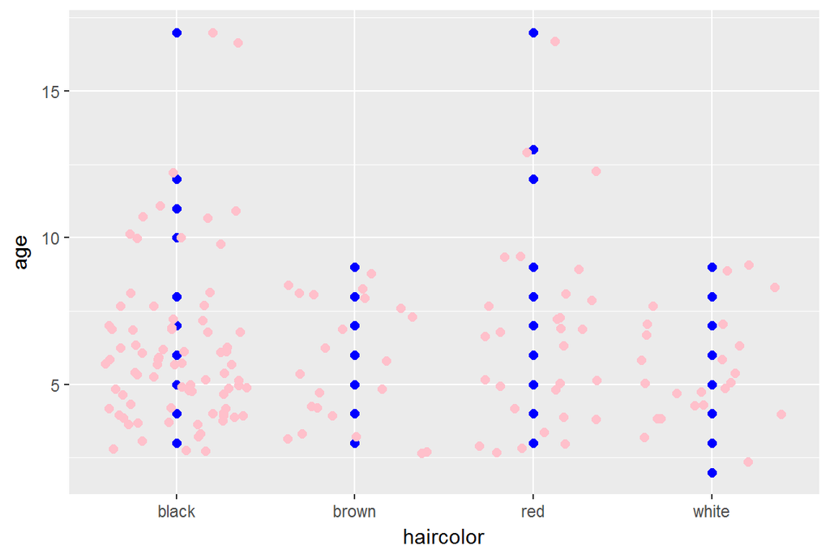

```r
p <- ggplot(catdata, aes(x=haircolor, y=age))+
  geom_point(col="blue", size=2) +
  geom_jitter(col="pink", size=2)
plot(p)
```

# Paramétrisation du geom

Evidemment tous **les geoms peuvent être paramétrés**. Je peux par exemple modifier la couleur de mes boîtes à moustache de la façon suivante:

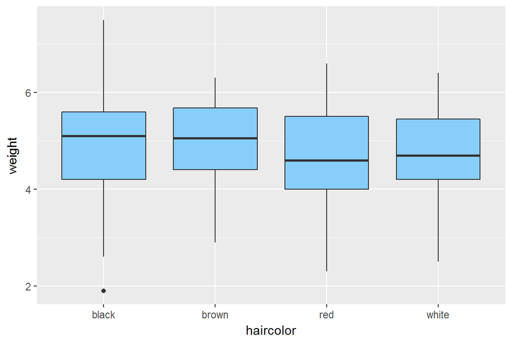

```r
p <- ggplot(catdata,aes(x=haircolor,y=weight)) +
  geom_boxplot(fill="lightskyblue")
plot(p)
```

Parmi les arguments les plus utilisés pour paramétrer les geoms, on peut citer:

- **color**: la couleur des lignes
- **fill**: la couleur de remplissage
- **linetype**: le type de ligne
- **size**: la taille des symboles ou l’épaisseur des lignes
- **alpha**: la transparence

# Paramétrisation du geom

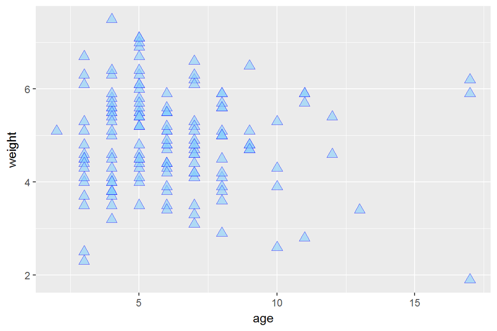

```r
p <- ggplot(catdata, aes(x=age, y= weight)) +
  geom_point(shape=24,
             color="blue",
             fill="lightskyblue",
             alpha=0.6,
             size=3)
plot(p)
```

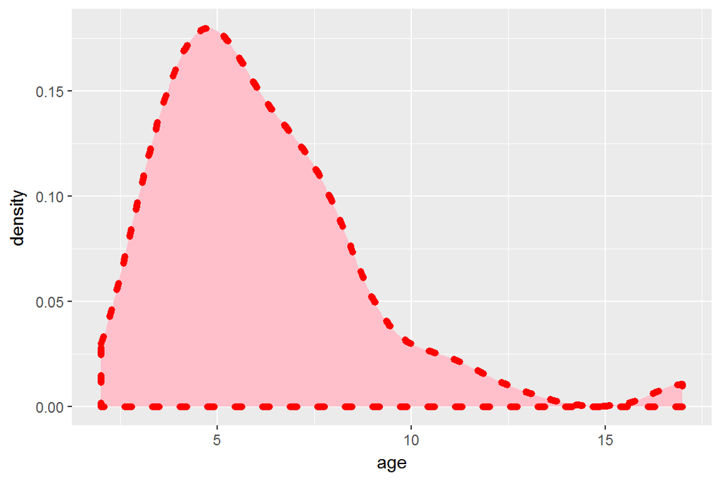

```r
p <- ggplot(catdata, aes(x=age)) +
  geom_density(color="red",
               fill="pink",
               linetype=3,
               lwd=2)
plot(p)
```